# MTH6139 Time Series

Coursework 1

Renjia Shi

March 17th 2024

Meta’s Prophet forecasting system.

at first we load the prophet library to get the co2 data frame

```r
#download the data
install.packages("remotes")
remotes::install_github('facebook/prophet@*release', subdir='R')
library(prophet)
#define the datafrome
co2.df = data.frame(ds=zoo::as.yearmon(time(co2)),y=co2)
#define the model
model = prophet(df = co2.df, weekly = TRUE, daily = TRUE)
#define the future value
future.df = make_future_dataframe(model, periods=8, freq="quarter")
#predict the future value
pred.df = predict(model, future.df)
#plot the graph
plot(model,pred.df)
```

after all of this process we can get a co2 concentration graph we can see this is a clear rising trend.

```
## Disabling weekly seasonality. Run prophet with weekly.seasonality=TRUE to override this.
```

```
## Disabling daily seasonality. Run prophet with daily.seasonality=TRUE to override this.
```

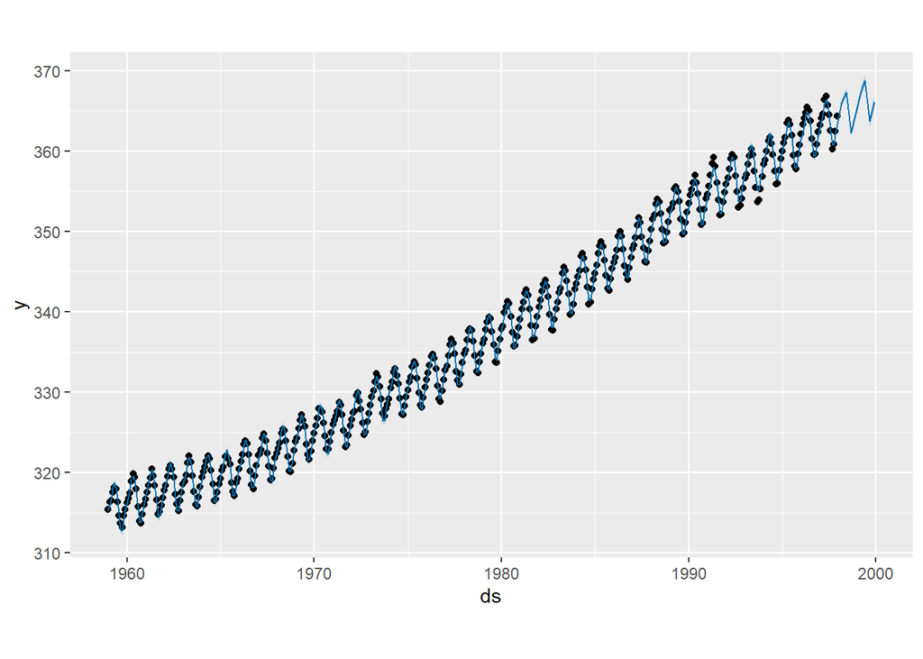

1.What is CO2 mean?

The co2 dataset refers to a time series data set that records the atmospheric concentrations of carbon dioxide (CO2) over time. By running “?co2” we can get a help of “Mauna Loa Atmospheric CO2 Concentration” Description Atmospheric concentrations of CO2 are expressed in parts per million (ppm) and reported in the preliminary 1997 SIO manometric mole fraction scale.

Usage co2

Format A time series of 468 observations; monthly from 1959 to 1997.

Details The values for February, March and April of 1964 were missing and have been obtained by interpolating linearly between the values for January and May of 1964.

Source Keeling, C. D. and Whorf, T. P., Scripps Institution of Oceanography (SIO), University of California, La Jolla, California USA 92093-0220. https://scrippsco2.ucsd.edu/data/atmospheric_co2/.

References Cleveland, W. S. (1993) Visualizing Data. New Jersey: Summit Press.

2.Explain the purpose of the project

The purpose of the project is to find how the co2 concentration change by the time. Also to find the trend and the seasonality of this regression model.

3.Display some charts and explain what you see

From the plot we can see this is a positive rising trend.

```r
#we can summary the co2 plot
summary(co2.df)
```

```
##        ds             y
##  Min.   :1959   Min.   :313.2
##  1st Qu.:1969   1st Qu.:323.5
##  Median :1978   Median :335.2
##  Mean   :1978   Mean   :337.1
##  3rd Qu.:1988   3rd Qu.:350.3
##  Max.   :1998   Max.   :366.8
```

```r
#we can randomly pick a specific number
specific_value <- co2.df[24, 2]
```

Meanwile we can analyze local data.

```r
#By running the fowwing code we can get the first ten data in co2.df
head(co2.df, 10)
```

```
      ds      y
```

1 Jan 1959 315.42

2 Feb 1959 316.31

3 Mar 1959 316.50

4 Apr 1959 317.56

5 May 1959 318.13

6 Jun 1959 318.00

7 Jul 1959 316.39

8 Aug 1959 314.65

9 Sep 1959 313.68

10 Otc 1959 313.18

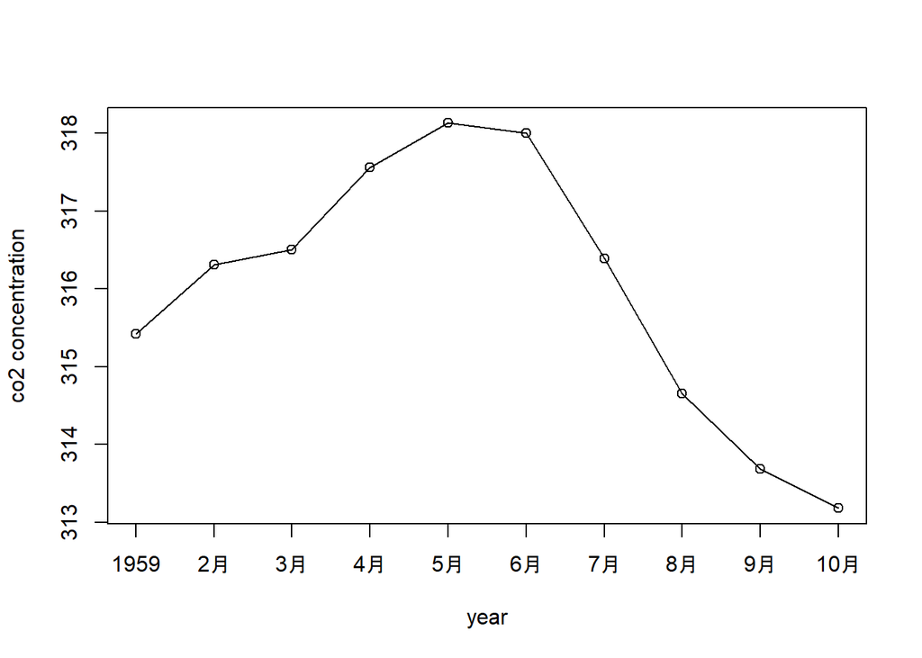

In this 10 data we can see in 1959 the co2 concentration didn’t change too much. We have the highest data in May. And the lowest data in October.

Then by running ‘max_y <- with(co2.df, max(y))’ we can get through all of the 468 datas, the largest data is 366.84.

```r
#By running this code we can get the last ten data in co2.df
tail(co2.df, 10)
```

```
       ds      y
```

459 Mar 1997 364.61

460 Apr 1997 366.40

461 May 1997 366.84

462 Jun 1997 365.68

463 Jul 1997 364.52

464 Aug 1997 362.57

465 Sep 1997 360.24

466 Oct 1997 360.83

467 Nov 1997 362.49

468 Dec 1997 364.34

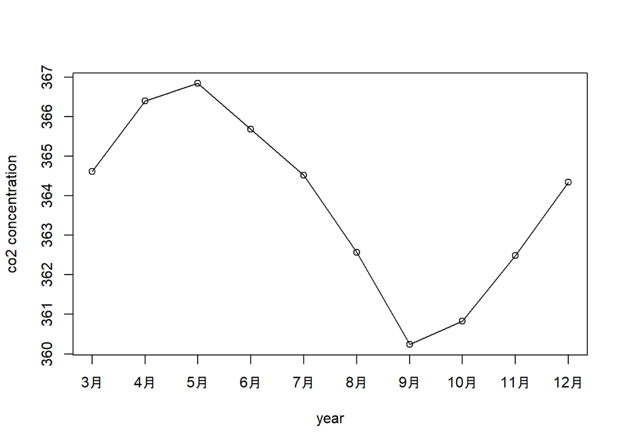

From the data we can see the largest data in here is 366.84. The smallest data is 360.24. This is not a clear rising or droing trend. we can conclude all of the plot, that as the time go, the concentration of co2 is keep rising, the air is more dirty.